# act_report

## Report: act_report (WeRateDogs)

### Authored by: Sulaiman Handu

WeRateDogs is a Twitter account that rates people's dogs with humorous comments about the dogs. The data used for this report has been gathered from three different sources. It was also assessed and cleaned to complete all of its wrangling processes. The resulting clean data were merged into a dataset and stored as a master dataset to be used to generate insights. The insights generated from the master datasets are key but not limited to the following:

- What are the most popular dog names
- What stages do we have in most dogs
- What ratings were mostly used to classify our dogs
- What is the correlation between retweet_count and favourite_count
- Most Favorite dogs
- What are the most used words in our tweets

### Most popular dog names

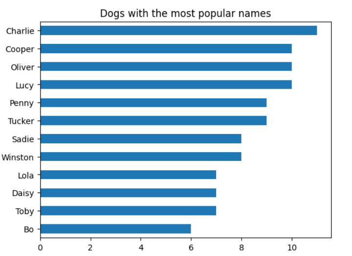

The bar chart shows the number of dogs having each of the most used names. Charlie is the most popular dog name in our data. There is a total of 11 dogs with name Charlie. Each of the names in the chart has been given to at least 6 other dogs. The chart was generated mainly to show names given to multiple dogs.

### The stage we have most dogs

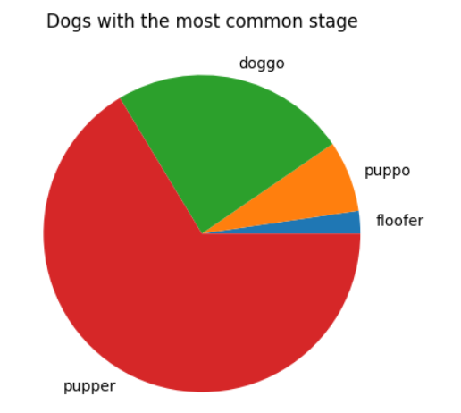

About 15% of the dog stages were specified (i.e., 303 of 1971). This is a very little percentage of the total data. Assumptions made were that the tweets are random and only a few randomly input the stage of their respective dogs. Most of the dogs tweeted about were Puppers and Doggos. The floofers were rarely tweeted about.

### The Ratings mostly used for the dogs

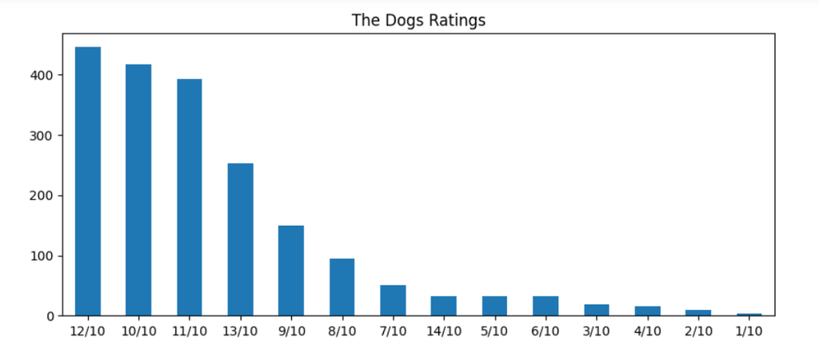

The charts contain about 99% of the dog's ratings. Only ratings with multiple entries had been chosen to be displayed. Over 75% of the dogs in this dataset have been given perfect or more than-perfect ratings. It means many of the dogs rated on WeRateDogs are considered good dogs.

### Correlation between retweets and favourite counts

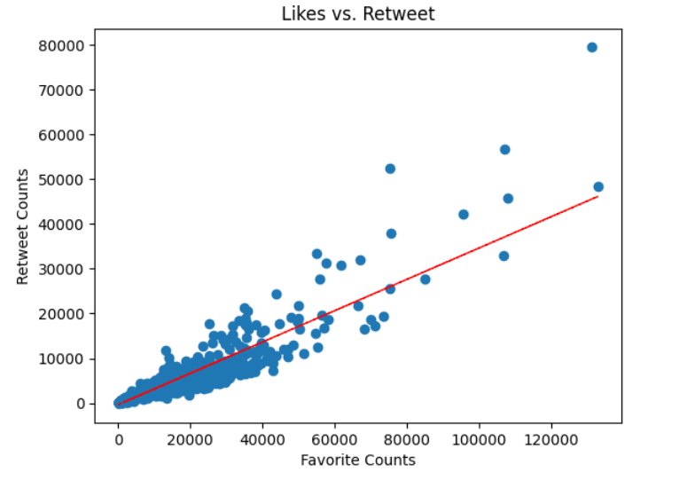

The Retweets and Likes are seen to be strongly and positively correlated with Pearson’s coefficient of 0.91. Two of the dogs were also noticed to have a distinct number of favorites which is over 120,000. Digging dipper into the most favorite dogs was based on this criterion and it was called the Top Two dogs.

### The Most Favourite Dogs

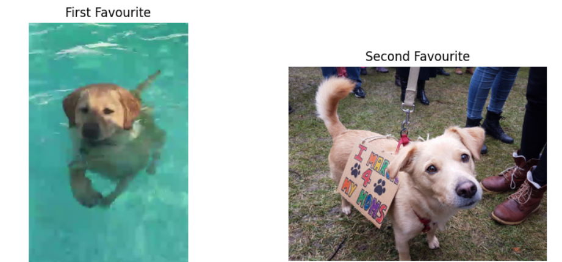

The Most favorite dogs are also known to be our top two dogs according to the analysis made. They have the same rating of 13/10. Those are more than perfect descriptions for a good dog.

### Most used word in tweets

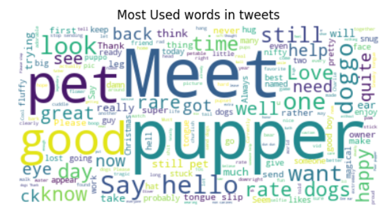

This word cloud shows that most ratings are for puppers and doggos. The general description of most tweets is humorous showing good, happy, meet, and rare amongst many more.